# Mice

Michel de Lange

8/7/2017

# Introduction

This is my first attempt to look at the mouse data. I have only looked at a tiny part of the spreadsheet: The CE19pos_B220 data. If I understand it correctly, we have measurements at timepoints 0,3,10,17,24 and 31. For each mouse, we have the number of live cells, and then the number of CD19pos_B220 cells. What matters is the proportion of CD19..220 to live cells. Mice come in three types: WT, Pound and Plt, and obviously we have male and female mice. We are interested in comparing Plt vs WT, and Pound vs. WT. We do not compare male mice with female mice. So the question is: Is there a difference in said proportion of cells at the different timepoints, in those groups of mice?

# the data

The following table shows the number of mice, by type and gender:

```
##
##  PLT2_female    PLT2_male Pound_female   Pound_male    WT_female
##            5            9            9            7            6
##      WT_male
##            4
```

So we have a total of 40 mice, 20 of each gender. Let’s look at the proportions of said cells, at the 6 timepoints: First the girl mice:

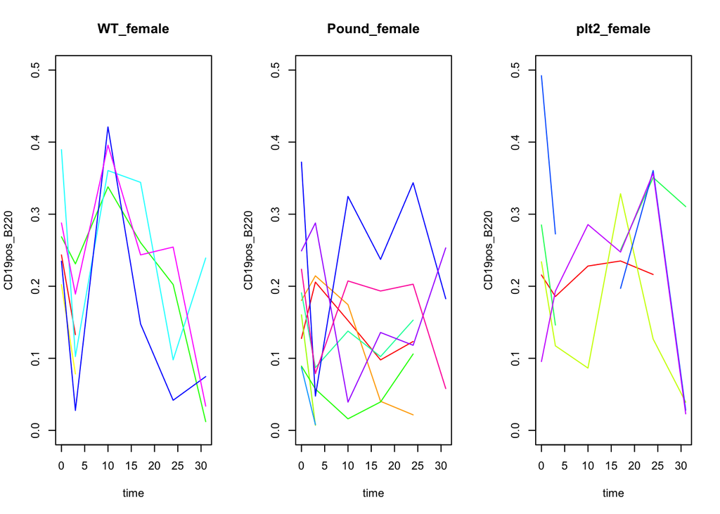

And now the boy mice:

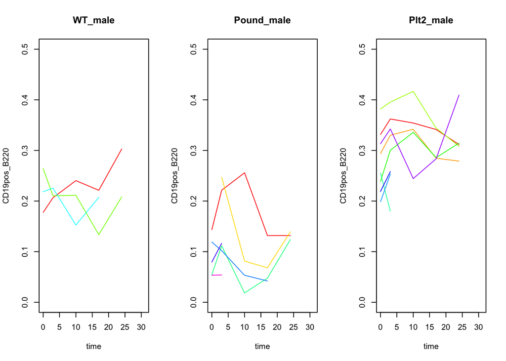

There seems to be a lot of individuality in mice. Whatever relationship there is, it is certainly not linear. Let’s look at boxplots. Here we see the information grouped together by type and gender, ignoring how it goes for an individual mouse. First, the girl mice again:

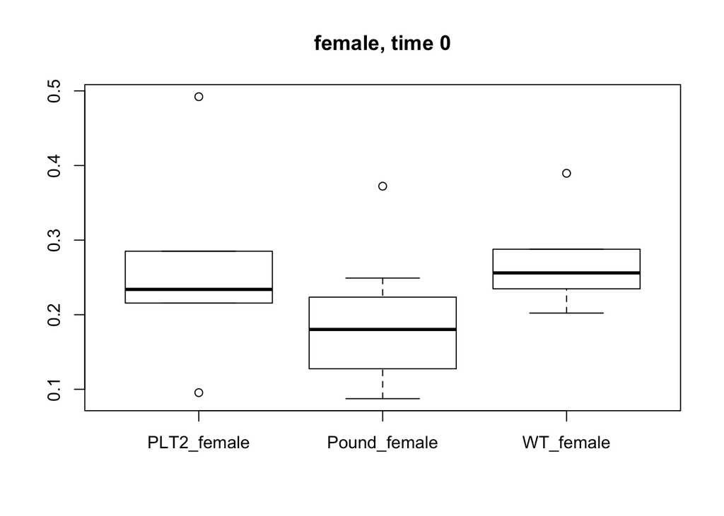

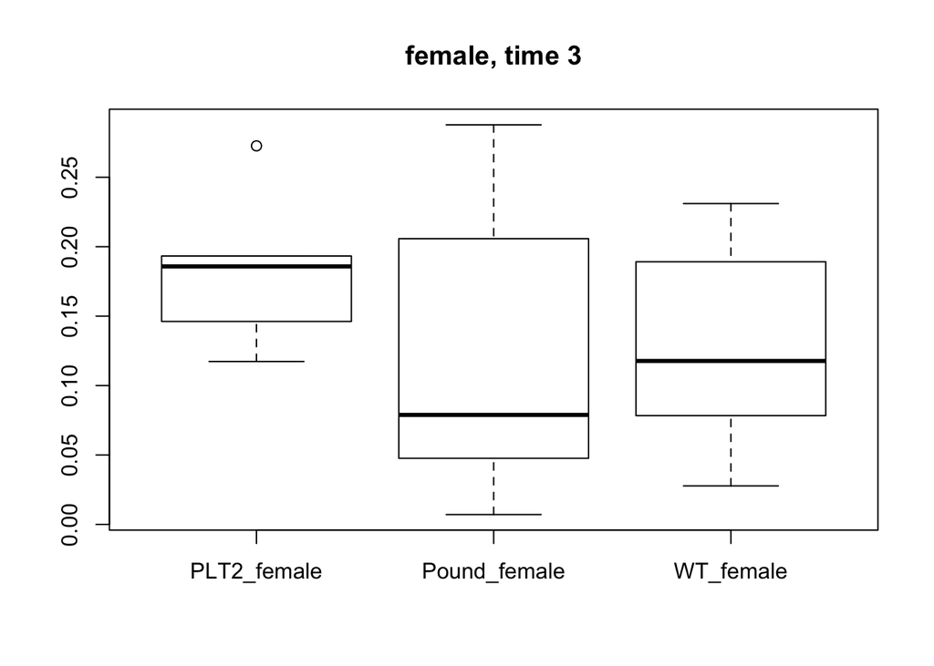

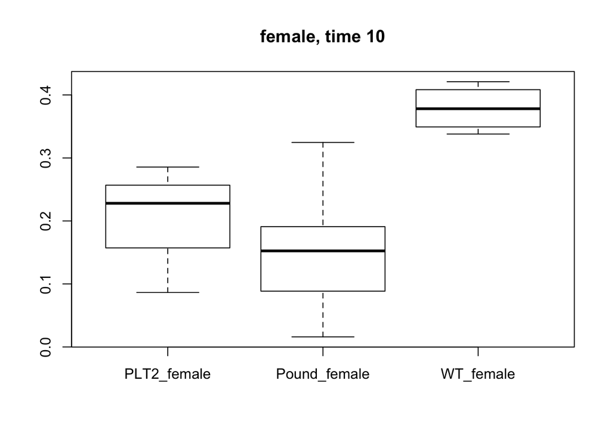

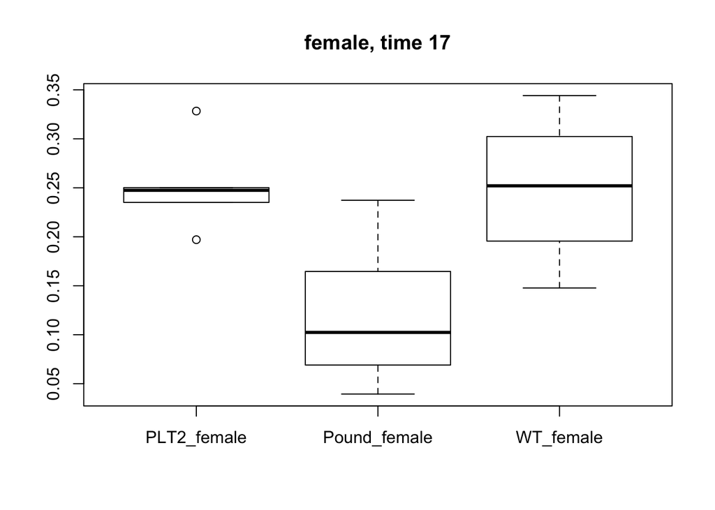

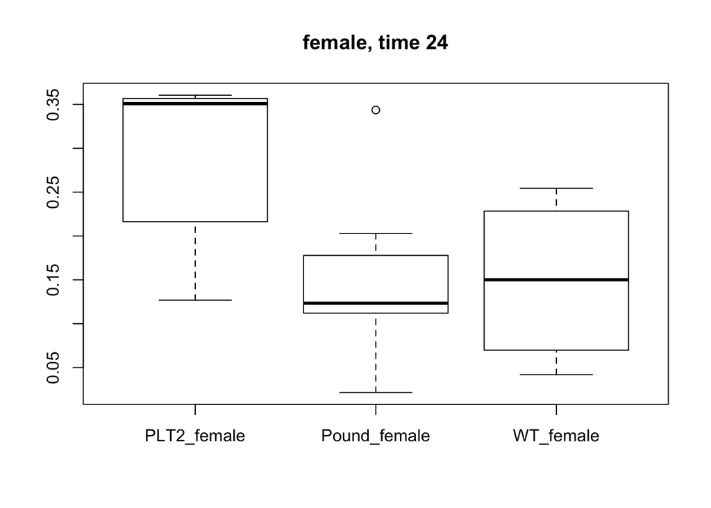

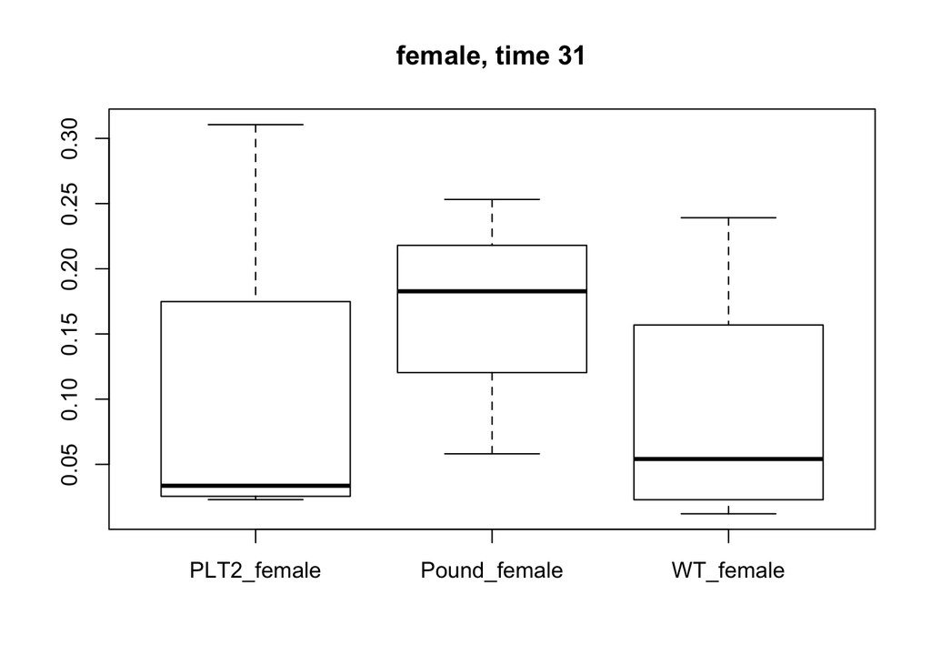

And now the boy mice:

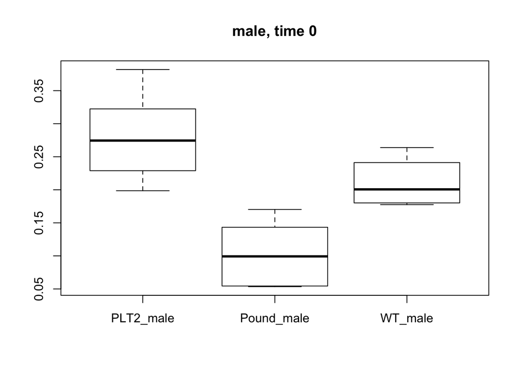

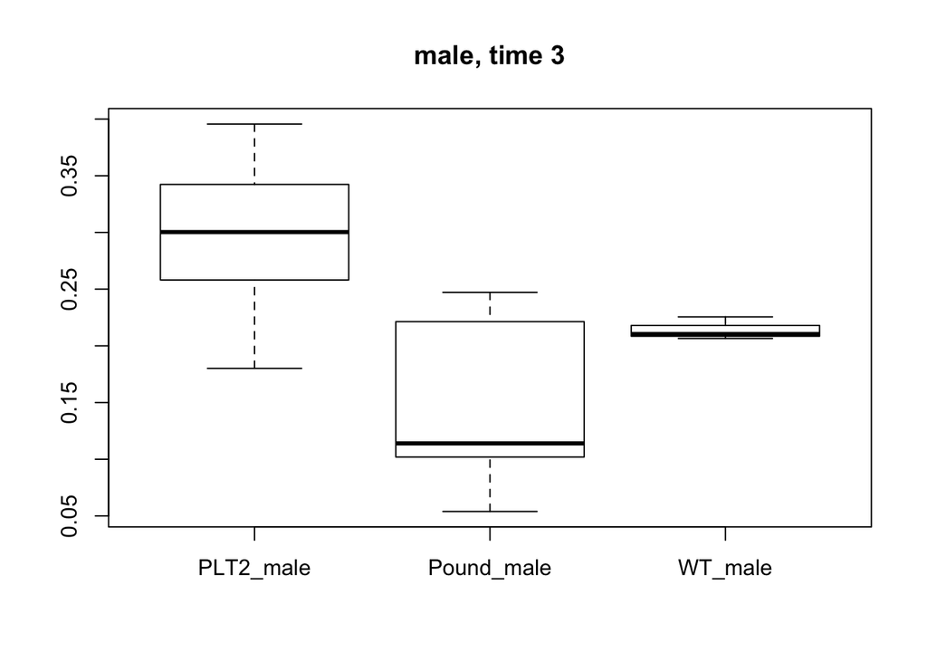

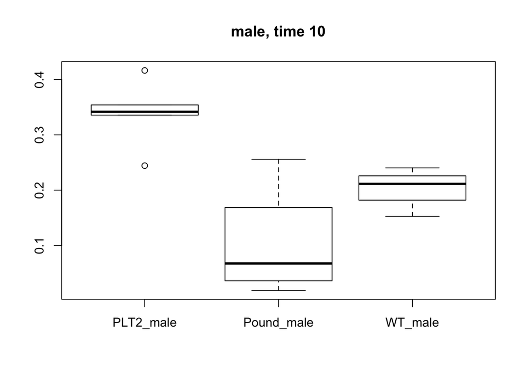

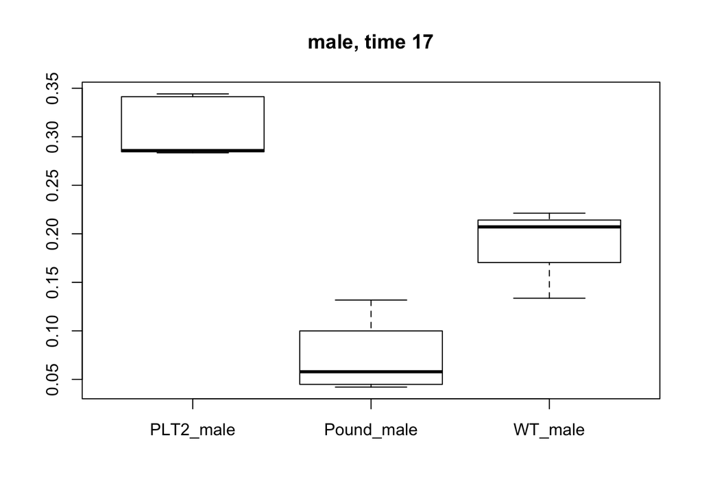

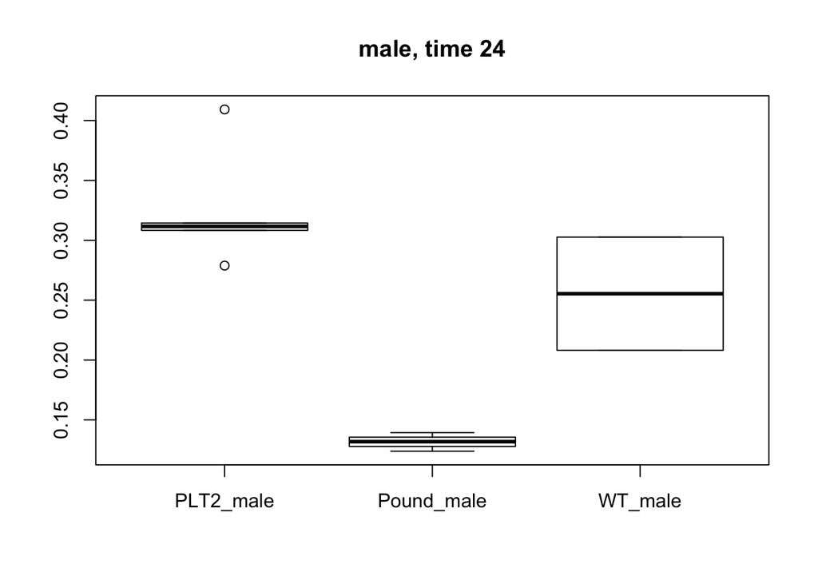